# Coordinate Diffusion

About lowering the resolution of spatial point data

recraft@pm.me https://recraft.me (Recraft.ME OÜ)https://github.com/recraft  
2018-11-12

Assume we have a leaflet map published with interactivity on the web, that has coordinate point features on it. Below is a low res screenshot of a website with such a map with bird inventory sites data in Sweden.

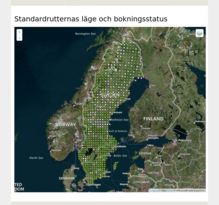

# Scraping coordinates

We can create a function to parse the leaflet features into a fairly tidy data frame. Lets look at the first ten rows of such parsed data.

```r
# for parsing
library(rvest)
library(httr)
library(readr)
library(jsonlite)
library(tibble)
library(dplyr)
library(stringr)

# for geotransform and visuals
library(sp)
library(raster)
library(raster)
library(leaflet)


parse_leaflet_coords <- function(url) {

  # get page content from url
  www <- url %>% GET %>% content(as = "text")

  # pick out features data used by leaflet
  tf <- tempfile()
  write_lines(www, tf)
  cmd <- paste("grep -o -e '\"features\":[[]{.*}}[]]'", tf)

  # convert to df
  json <- fromJSON(paste0("{", system(cmd, intern = TRUE), "}"),
    flatten = TRUE)

  unlink(tf)

  as_tibble(json$features)

}

# parse leaflet coordinates for the routes_night url
df <- parse_leaflet_coords(routes_std)

# tidy the data to allow for easier plotting
p <-
  df %>%
  mutate(is_booked = ifelse(is.na(str_match(html, "green")), FALSE, TRUE)) %>%
  mutate(grid_code = str_extract(label, "\\w{5}")) %>%
  mutate(grid_desc = str_replace(label, "\\w{5}\\s+(\\w+)", "\\1")) %>%
  mutate(color = ifelse(is_booked, "darkgreen", "white")) %>%
  dplyr::select(grid_code, grid_desc, popup, lon, lat, is_booked, color) %>%
  arrange(lon, lat)

paged_table(p %>% dplyr::select(-popup) %>% slice(1:10))
```

| grid_code | grid_desc | lon | lat | is_booked | color |
| --- | --- | --- | --- | --- | --- |
| 09A7H | HEDÄNGEN | 11.25174 | 58.87900 | TRUE | darkgreen |
| 09A2H | KOLMYRARNA | 11.28098 | 58.65527 | TRUE | darkgreen |
| 08A7H | HUNNEBOSTRAN | 11.30978 | 58.43152 | TRUE | darkgreen |
| 08A2H | BONDEN | 11.33815 | 58.20776 | TRUE | darkgreen |
| 09B7C | MELLANKORNSJÖN | 11.68403 | 58.89353 | TRUE | darkgreen |
| 09B2C | KYNNEFJÄLL | 11.71052 | 58.66968 | TRUE | darkgreen |
| 08B7C | HENSBACKA | 11.73661 | 58.44580 | TRUE | darkgreen |
| 08B2C | MYCKLEBY | 11.76230 | 58.22192 | TRUE | darkgreen |
| 07B7C | HAKEFJORD | 11.78762 | 57.99802 | TRUE | darkgreen |
| 07B2C | BJÖRLANDA | 11.81256 | 57.77410 | TRUE | darkgreen |

# Fitting a grid to the points

We now have the coordinates so we can create spatial points and attempt to find a spatial grid that fits the points given a certain not necessarily modest tolerance for deviations.

```r
# leaflet uses EPSG:4326 so we create spatial points based on the data
# and fit points to a grid

points <- SpatialPointsDataFrame(
  data.frame(p$lon, p$lat),
  data = p, proj4string = CRS("+init=epsg:4326")
)

gt <- points2grid(points, tolerance = 0.90)

sg <- SpatialGrid(
  grid = gt,
  proj4string = CRS("+init=epsg:4326")
)

# convert spatial grid to polygons for display in leaflet
spdf <- as(sg, "SpatialPolygons")

m <-
  leaflet() %>%
  addProviderTiles("Stamen.Watercolor",
                   options = providerTileOptions(opacity = 0.25)) %>%
  addPolygons(data = spdf, weight = 1, color = "darkgray") %>%
  addCircles(lng = points$lon, lat = points$lat,
             radius = 1, #stroke = FALSE,
             color = p$color,
             fill = p$color, opacity = 1,
             popup = p$popup,
             label = p$grid_code)


m
```

[interactive chart not shown]

Looking at the map we see that points fit the grid well at the bottom but not at the top, where coordinates seems to be more widely space out. We suspect some warped grid would perhaps fit the points even better. Perhaps a standard Swedish grid in another projection has been used?

We test with the Swedish grid from the “swedishbutterflies” R package.

```r
# a Swedish grid is available as a raster layer in the swedishbutterflies package
library(swedishbutterflies)

grid <- sebms_swe_grid

rl <- raster(extent(grid), nrows = 62, ncols = 28,
             crs = projection(grid))

gt <- getGridTopology(as(rl, "SpatialGrid"))

sg <- SpatialGrid(
  grid = gt,
  proj4string = projection(grid)
)

# transform it to spatial polygons in the leaflet default projection
spdf <- spTransform(as(sg, "SpatialPolygons"), CRS("+init=epsg:4326"))

# inspect results when plotting the points and the standard swedish grid
m <-
  leaflet() %>%
  addProviderTiles("Stamen.Watercolor",
                   options = providerTileOptions(opacity = 0.25)) %>%
  addPolygons(data = spdf, weight = 1, color = "darkgray") %>%
  addCircles(lng = points$lon, lat = points$lat,
             radius = 1, #stroke = FALSE,
             color = p$color,
             fill = p$color, opacity = 1,
             popup = p$popup,
             label = p$grid_code)


m
```

[interactive chart not shown]

We can confirm visually in the plot that grid cell centroid coords match the points well.

# Diffusing coordinates

Now let’s say we have positions that we want to publish but at a lower resolution - ie diffused - in order to make it more difficult to reengineer site data that may be protected or sensitive. In other words we want to do a lossy tranformation on the coordinate data where we snap it to cell centroid coordinates of a lower resolution grid.

Depending on how coarse the lower resolution grid is, duplicated coordinates will be more frequent than in the original point data. The lower the resolution, the more overlaps, so we may also need some kind of optional jitter to make it easier to visually distinguish between positions that overlap after the transformation but that originally did not overlap.

## Diffusion function

Here is an example of a function that take spatial points and return diffused spatial points.

```r
library(raster)
library(sp)
library(leaflet)
library(mapview)
library(swedishbutterflies)

#' Diffuse spatial points in order to obscure exact positions.
#'
#' This function is intended to diffuse spatial points using a lossy transformation,
#' where coordinate positions are changed, snapping to the centroid point of a coarser grid
#' and then jittering positions to avoid overlap. If no grid is specified, a grid will
#' be calculated from the point data.
#'
#' @param points SpatialPoints object with the coordinates
#' @param grid SpatialGrid object with the coarser grid to snap the points to
#' @param use_swe_grid logical defaulting to TRUE indicating that if the grid parameter is missing, a specific Swedish grid is used for aggregate points
#' @param jitter logical defaulting to TRUE indicating that new positions should be jittered to avoid overlaps
#' @importFrom raster extent projection dplyr
#' @importFrom sp points2grid over CRS
#' @export

diffuse <- function(points, grid, use_swe_grid = TRUE, jitter = TRUE) {

  if (missing(grid)) {
    if (use_swe_grid) {
      grid <- as(raster(extent(sebms_swe_grid),
        nrows = 62, ncols = 28,
        crs = projection(sebms_swe_grid)), "SpatialGrid")
    } else {
      grid <- SpatialGrid(
        points2grid(points, tolerance = 0.7),
        proj4string = CRS(proj4string(points))
      )
    }
  }

  idx <- over(points, grid)

  new_coords <- as.data.frame(coordinates(grid)[idx, ])

  if (jitter) {
    dx <- jitter(new_coords$s1)
    dy <- jitter(new_coords$s2)
    new_coords <- data.frame(lon = dx, lat = dy)
  }

  diffused_points <- SpatialPoints(
    coords = new_coords,
    proj4string = CRS(proj4string(points))
  )

  return (diffused_points)

}
```

Many things can be improved when it comes to the implementation of this function but are omitted for simplicity and readability. For example, documentation of the function with more usage examples, argument checking, jittering parameters and tolerance levels for the auto-gridding, error handling etc.

But let’s skip those details for now and instead see how the function can be used to diffuse point data.

# Diffusing real point data

Let’s see how this function can be used.

To do this, first we need some example point data and we can start from a data frame with two columns of longitude and latitude coordinates and add some info on the coordinate reference system used for the coordinates.

In Sweden, coordinates are traditionally often specified using formats known as RT38, RT90 and SWEREF99 with various variations.

| EPSG | Abbrev | GCS |
| --- | --- | --- |
| 3028 | RT38_0_gon | RT38 |
| 3029 | RT38_25_gon_O | RT38 |
| 3027 | RT38_25_gon_V | RT38 |
| 3030 | RT38_5_gon_O | RT38 |
| 3026 | RT38_5_gon_V | RT38 |
| 3025 | RT38_75_gon_V | RT38 |
| 3022 | RT90_0_gon | RT90 |
| 3023 | RT90_25_gon_O | RT90 |
| 3021 | RT90_25_gon_V | RT90 |
| 3024 | RT90_5_gon_O | RT90 |

[output cut: 15 more lines]

Coordinates in our example are assumed to be specified in [RT90 2.5 gon V (Transverse Mercator)](https://georepository.com/crs_3021/RT90-2-5-gon-V.html) so we need to provide this CRS info so that points can be reprojected for visual display using Leaflet interactive web maps - which use [EPSG:4326](https://epsg.io/4326) by default.

```r
# original point data
original <- SpatialPoints(
  coords = sebms_data_sites,
  proj4string = CRS("+proj=tmerc +lat_0=0 +lon_0=15.80827777777778 +k=1 +x_0=1500000 +y_0=0 +ellps=bessel +units=m +no_defs")
)

# diffuse the point data accepting fcn parameter defaults
diffused <- diffuse(original)

# finally display the results (original points, diffused points and the grid)
m <-
  mapview(original, color = "darkgreen", cex = 1) +
  mapview(diffused, color = "darkred", cex = 1) +
  mapview(sebms_swe_grid, color = "gray")

m
```

[interactive chart not shown]

If we want to provide a custom aggregation grid that is more coarse we can do so.

```r
coarse_grid <- as(raster(extent(sebms_swe_grid), nrows = 6, ncols = 6,
        crs = projection(sebms_swe_grid)), "SpatialGrid")

diffused <- diffuse(original, coarse_grid)

coarse_grid_polys <- as(coarse_grid, "SpatialPolygons")

m <-
  mapview(original, color = "darkgreen", cex = 1) +
  mapview(diffused, color = "darkred", cex = 1) +
  mapview(coarse_grid_polys, color = "gray")

m
```

[interactive chart not shown]

When using such a coarse grid, it may be too coarse so that a clustering effect will be noticeable in the diffused point data.